# Machine Learning:

## A Classification problem on Iris data using K-means Clustering and Random forests algorithm

### Mrinal Sarkar

### 1. Introduction

### 2. Problem Definition

### 3. Solution using Python

#### A. Importing Libraries

#### B. Importing Data

### 4. Data Statistics

### 5. Data Visualization

### 6. Finding Optimum number of cluster (Elbow Method)

### 7. K-means Clustering

#### A. Comparison between actual and predicted clustering

#### B. Comment

### 8. Random forests algorithm

### 9. To test the Accuracy of the model

### 10. Finding Important Features in the model

### 11. Generating the Model based on Important Features

### 12. Accuracy Comparison

### 12. Conclusion

## Introduction

K-Means Clustering is one of the popular unsupervised machine learning algorithms. Generally, clusters or groups are asked to find when we don’t have labeled data. This algorithm classify the data without being trained with labeled data. Once the whole data is classified in different clusters, any new data can be assigned to the most relevant one.

On the other hand, Random forests is a supervised learning algorithm. It creates decision trees on randomly selected data samples, gets prediction from each tree and selects the best solution by means of voting. This method can also calculate the importance of different features in predicting. We can build the model based on important features only and then test the model.

## Problem Definition

Given Iris data set from scikit learn. We apply K-means clustering to classify the data. This dataset consists of three species of Iris (Iris setosa, Iris virginica and Iris versicolor) each having 50 samples. The number of feature variables is four: length and width of sepals and petals.

At first, we assume that we do not know the different species of the Iris flowers and apply K-means algorithm to classify the whole dataset into different clusters. Our goal is to observe, whether we get the cluster no as 3 or not.

Next, we first label the data and then will split the whole data into train and test set. We will apply Random forests algorithm to train the model using the train dataset and then will apply to the test set. Finally we calculate the confusion matrix to understand the quality of the fiting model. Another, important part is to reduce the number of features based on their importance in prediction. We then rebuild the model and want to compare accuracy for both the cases.

## Solution using Python:

### Importing Libraries

```python
import numpy as np
import pandas as pd
import seaborn as sns
import matplotlib.pyplot as plt
```

### Importing Data

We import the library with Iris dataset form scikit learn

```python
from sklearn.datasets import load_iris
```

```python
load_iris
```

```
<function sklearn.datasets.base.load_iris(return_X_y=False)>
```

```python
#to create an object variable called iris with the data
iris=load_iris()
#iris.data
```

Different class types

```python
iris.target_names
```

```
array(['setosa', 'versicolor', 'virginica'], dtype='<U10')
```

```python
iris.feature_names
```

```
['sepal length (cm)',
 'sepal width (cm)',
 'petal length (cm)',
 'petal width (cm)']
```

## Data Statistics

```python
#To create the dataframe with the features
df=pd.DataFrame(iris.data,columns=iris.feature_names)
```

```python
df.head()
```

|  | sepal length (cm) | sepal width (cm) | petal length (cm) | petal width (cm) |
| --- | --- | --- | --- | --- |
| 0 | 5.1 | 3.5 | 1.4 | 0.2 |
| 1 | 4.9 | 3.0 | 1.4 | 0.2 |
| 2 | 4.7 | 3.2 | 1.3 | 0.2 |
| 3 | 4.6 | 3.1 | 1.5 | 0.2 |
| 4 | 5.0 | 3.6 | 1.4 | 0.2 |

```python
df.info()
```

```
<class 'pandas.core.frame.DataFrame'>
RangeIndex: 150 entries, 0 to 149
Data columns (total 4 columns):
sepal length (cm)    150 non-null float64
sepal width (cm)     150 non-null float64
petal length (cm)    150 non-null float64
petal width (cm)     150 non-null float64
dtypes: float64(4)
memory usage: 4.8 KB
```

```python
df.describe()
```

|  | sepal length (cm) | sepal width (cm) | petal length (cm) | petal width (cm) |
| --- | --- | --- | --- | --- |
| count | 150.000000 | 150.000000 | 150.000000 | 150.000000 |
| mean | 5.843333 | 3.057333 | 3.758000 | 1.199333 |
| std | 0.828066 | 0.435866 | 1.765298 | 0.762238 |
| min | 4.300000 | 2.000000 | 1.000000 | 0.100000 |
| 25% | 5.100000 | 2.800000 | 1.600000 | 0.300000 |
| 50% | 5.800000 | 3.000000 | 4.350000 | 1.300000 |
| 75% | 6.400000 | 3.300000 | 5.100000 | 1.800000 |
| max | 7.900000 | 4.400000 | 6.900000 | 2.500000 |

## Data Visualization

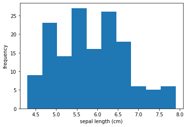

```python
plt.hist(df["sepal length (cm)"])
plt.xlabel('sepal length (cm)')
plt.ylabel('frequency')
```

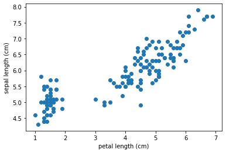

```python
plt.scatter(df["petal length (cm)"],df["sepal length (cm)"])
plt.xlabel('petal length (cm)')
plt.ylabel('sepal length (cm)')
```

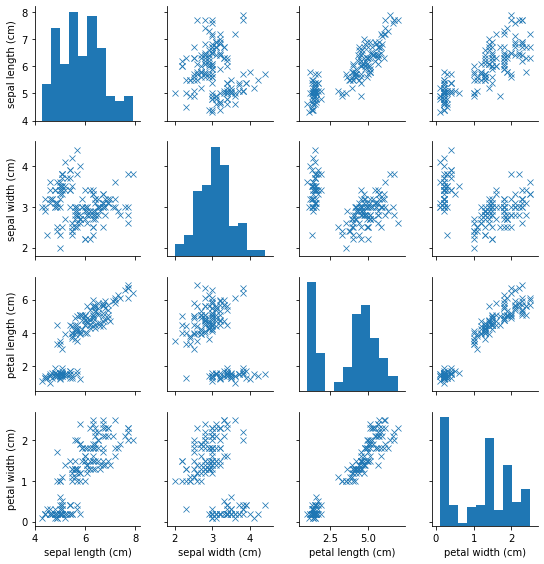

```python
g = sns.pairplot(df, hue=None, markers='x', size = 2.0)
```

## Finding Optimum number of cluster (Elbow Method)

To find the optimum nuber of cluster for classification, we will now apply Elbow method on this Iris dataset.

```python
#Finding the optimum number of clusters for k-means classification
from sklearn.cluster import KMeans
Sum_of_Inertias = []

for i in range(1, 12):
    kmeans = KMeans(n_clusters = i, init = 'k-means++', max_iter = 300, n_init = 10, random_state = 1)
    kmeans.fit(iris.data)
    Sum_of_Inertias.append(kmeans.inertia_)
```

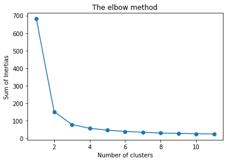

```python
#Plotting the results onto a line graph, allowing us to observe 'The elbow'
plt.plot(range(1, 12), Sum_of_Inertias,'o-')
plt.title('The elbow method')
plt.xlabel('Number of clusters')
plt.ylabel('Sum of Inertias') #within cluster sum of squares
plt.show()
```

Comment: The Elbow method shows that the optimum no of clusters we can choose is 3.

Next we will apply kmeans-clustering on the Iris dataset.

## K-means Clustering

```python
#Applying kmeans to the dataset / Creating the kmeans classifier
kmeans = KMeans(n_clusters = 3, init = 'k-means++', max_iter = 300, n_init = 10, random_state = 1)
y_kmeans = kmeans.fit_predict(iris.data)
```

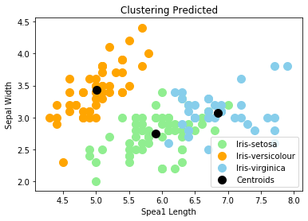

```python
#Visualising the clusters
plt.scatter(iris.data[y_kmeans == 0, 0], iris.data[y_kmeans == 0, 1], s = 100, c = 'lightgreen', label = 'Iris-setosa')
plt.scatter(iris.data[y_kmeans == 1, 0], iris.data[y_kmeans == 1, 1], s = 100, c = 'orange', label = 'Iris-versicolour')
plt.scatter(iris.data[y_kmeans == 2, 0], iris.data[y_kmeans == 2, 1], s = 100, c = 'skyblue', label = 'Iris-virginica')

#Plotting the centroids of the clusters
plt.scatter(kmeans.cluster_centers_[:, 0], kmeans.cluster_centers_[:,1], s = 100, c = 'black', label = 'Centroids')

plt.legend()
plt.title('Clustering Predicted')
plt.xlabel('Spea1 Length')
plt.ylabel('Sepal Width')
```

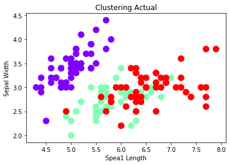

```python
X = iris.data[:, :2]
y = iris.target
plt.scatter(X[:,0], X[:,1], c=y, cmap='rainbow', s=100)
plt.title('Clustering Actual')
plt.xlabel('Spea1 Length')
plt.ylabel('Sepal Width')
```

#### Comment:

1. We thus see that the whole dataset can be grouped into three clusters which is in agreement with the data (as we know already).
2. The plot named "Clustering Predicted" shows the classification of the data into three clusters along with the positions of their centroids as obtained using K-means clustering technique.
3. The actual data showing the original three clusters are shown in the plot named "Clustering Actual" to compare with the predicted one.

In the next section we use Random-forests classification technique on the same dataset. Here we will first label the data and then will split the whole data into train and test set. We will train the model using the train dataset and then will apply to the test set. Finally we calculate the confusion matrix to understands the quality of the fiting model.

# Implementation of Random forests Algorithm

We need to add an extra column for the species name in the dataframe for classification.

```python
df['species']=pd.Categorical.from_codes(iris.target, iris.target_names)
df.head()
```

|  | sepal length (cm) | sepal width (cm) | petal length (cm) | petal width (cm) | species |
| --- | --- | --- | --- | --- | --- |
| 0 | 5.1 | 3.5 | 1.4 | 0.2 | setosa |
| 1 | 4.9 | 3.0 | 1.4 | 0.2 | setosa |
| 2 | 4.7 | 3.2 | 1.3 | 0.2 | setosa |
| 3 | 4.6 | 3.1 | 1.5 | 0.2 | setosa |
| 4 | 5.0 | 3.6 | 1.4 | 0.2 | setosa |

Now the task is to separate independent (features) and dependent variables (labels). Next we split the whole data in training and test set. To train the model, we need to split the whole data in training and test part.

```python
# Import train_test_split function
from sklearn.model_selection import train_test_split
```

```python
features=df.columns[:4]
features
```

```
Index(['sepal length (cm)', 'sepal width (cm)', 'petal length (cm)',
       'petal width (cm)'],
      dtype='object')
```

### Train and test data set

```python
#train dataset
X=df[['sepal length (cm)', 'sepal width (cm)', 'petal length (cm)',
       'petal width (cm)']]
#test data
y=df['species']
#to split into train and test dataset
X_train, X_test, y_train, y_test = train_test_split(X, y, test_size=0.3)
```

Now, we need to train the model using the training datasets and wll apply on test dataset to get the prediction.

```python
from sklearn.ensemble import RandomForestClassifier
clf=RandomForestClassifier(n_estimators=100)
clf.fit(X_train,y_train)
y_pred=clf.predict(X_test)
y_pred
```

```
array(['versicolor', 'setosa', 'versicolor', 'versicolor', 'versicolor',
       'versicolor', 'versicolor', 'setosa', 'versicolor', 'virginica',
       'setosa', 'virginica', 'setosa', 'versicolor', 'setosa', 'setosa',
       'versicolor', 'versicolor', 'versicolor', 'setosa', 'versicolor',
       'virginica', 'setosa', 'versicolor', 'setosa', 'setosa', 'setosa',
       'setosa', 'versicolor', 'virginica', 'virginica', 'setosa',
       'versicolor', 'versicolor', 'setosa', 'setosa', 'versicolor',
       'setosa', 'versicolor', 'virginica', 'setosa', 'setosa',
       'virginica', 'virginica', 'setosa'], dtype=object)
```

## To test the Accuracy of the model

### Confusion Matrix

We need to check the accuracy of the model.

We will calculate the Confusion Matrix elements for this purpose.

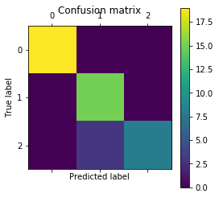

```python
from sklearn.metrics import confusion_matrix
# Compute confusion matrix
cm = confusion_matrix(y_test, y_pred)
plt.matshow(cm)
plt.title('Confusion matrix')
plt.colorbar()
plt.ylabel('True label')
plt.xlabel('Predicted label')
plt.show()
```

```python
cm
```

```
array([[19,  0,  0],
       [ 0, 15,  0],
       [ 0,  3,  8]])
```

```python
from sklearn.metrics import accuracy_score
accuracy=accuracy_score(y_test, y_pred)
accuracy
```

```
0.9333333333333333
```

Given the four features of one iris flower, we can now make a prediction which type it belong to. Say for example, for one flower, the features are the following:

sepal length = 4.6 (cm)

sepal width = 3.1(cm)

petal length = 1.5(cm)

petal width =0.2(cm).

To predict the species of the flower, we apply the model to it.

```python
clf.predict([[4.6, 3.1, 1.5, 0.2]])
```

```
array(['setosa'], dtype=object)
```

We can look at the dataset and see that this truly belong to the species "setosa".

## Finding Important Features in the model

Usually, when a dataset has many number of features, it is important to find out which are important. Random forest helps us find relative importance or contribution of each feature in the prediction. It computes the relevance score of each feature in the training phase.

This will help us to select important features and reject the other features which are less important.

We use the feature importance variable to see feature importance scores.

```python
RandomForestClassifier(bootstrap=True, class_weight=None, criterion='gini',
            max_depth=None, max_features='auto', max_leaf_nodes=None,
            min_impurity_decrease=0.0, min_impurity_split=None,
            min_samples_leaf=1, min_samples_split=2,
            min_weight_fraction_leaf=0.0, n_estimators=100, n_jobs=1,
            oob_score=False, random_state=None, verbose=0,
            warm_start=False)

feature_imp = pd.Series(clf.feature_importances_,index=iris.feature_names).sort_values(ascending=False)
feature_imp
```

```
petal width (cm)     0.486397
petal length (cm)    0.408679
sepal length (cm)    0.081583
sepal width (cm)     0.023342
dtype: float64
```

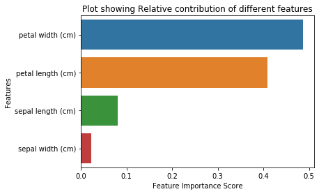

```python
import seaborn as sns
%matplotlib inline
sns.barplot(x=feature_imp, y=feature_imp.index)
plt.xlabel('Feature Importance Score')
plt.ylabel('Features')
plt.title("Plot showing Relative contribution of different features")
#plt.legend()
plt.show()
```

So it is clear that, out of these four features, sepal width and sepal length have less contribution in predicting the model.

We can now drop the least important feature (sepal width) in predicting the model and now will build Random forests model based on only the three remaining features.

## Generating the Model based on Important Features

We build the model based on the important features only.

One advantage of the feature reduction is, it will take less time to train the model too.

We split the dataset into features and labels. Here we will consider three features only and build the model as before.

```python
#new_train dataset
X=df[['sepal length (cm)', 'petal length (cm)',
       'petal width (cm)']]
#test data
y=df['species']
#to split into train and test dataset
X_train, X_test, y_train, y_test = train_test_split(X, y, test_size=0.3, random_state=0)
```

```python
#Create a Gaussian Classifier
clf_modified=RandomForestClassifier(n_estimators=100)

#Train the model using the training sets y_pred=clf.predict(X_test)
clf_modified.fit(X_train,y_train)

# prediction on test set
y_pred=clf_modified.predict(X_test)
```

```python
y_pred
```

```
array(['virginica', 'versicolor', 'setosa', 'virginica', 'setosa',
       'virginica', 'setosa', 'versicolor', 'versicolor', 'versicolor',
       'virginica', 'versicolor', 'versicolor', 'versicolor',
       'versicolor', 'setosa', 'versicolor', 'versicolor', 'setosa',
       'setosa', 'virginica', 'versicolor', 'setosa', 'setosa',
       'virginica', 'setosa', 'setosa', 'versicolor', 'versicolor',
       'setosa', 'virginica', 'versicolor', 'setosa', 'virginica',
       'virginica', 'versicolor', 'setosa', 'virginica', 'versicolor',
       'versicolor', 'virginica', 'setosa', 'virginica', 'setosa',
       'setosa'], dtype=object)
```

### Confusion Matrix

Now, we will check the accuracy of the new model. We will look at the confusion matrix first.

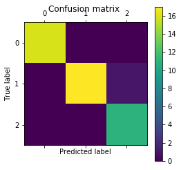

```python
cm_modified = confusion_matrix(y_test, y_pred)
plt.matshow(cm_modified)
plt.title('Confusion matrix ')
plt.colorbar()
plt.ylabel('True label')
plt.xlabel('Predicted label')
plt.show()
```

```python
cm_modified
```

```
array([[16,  0,  0],
       [ 0, 17,  1],
       [ 0,  0, 11]])
```

```python
accuracy=accuracy_score(y_test, y_pred)
accuracy
```

```
0.9777777777777777
```

Here, we note that, the accuracy increased as compared to previous case.

The Iris dataset available to us has small number of datapoints. Generally, the features reduction techniques are quite helpful when we have a large datasets with too many feature variables.

It takes less time to train the model with less number of features.

The accuracy is also expected to increase compared to the case where all features are involved to train the model.

# Conclusion:

1. Given the Iris dataset, we apply Random forests algorithm on it to classify them in terms of different species.
2. We calculate the confusion matrix and test the accuracy of the model.
3. The important features in predicting the model are also found.
4. Sepal width turns out to be the least important feature in predicting the different species.
5. We rebuild the model based on the other three important features and make the prediction.
6. The accuracy is also tested in this case. It increased as compared to previous case. Sometimes in our case, the prediction with all features might also give a very hagh accuracy and both the model (the model before and after features reduction) might give same accuracy. We believe that this is the effect of small number of datapoints.
7. The better accuracy is expected for large datasets having too many feature variables.